# **Panorama da inflação**

Os principais índices de inflação do Brasil, apontam em dezembro de 2016 um avanço da inflação de em média **0.33%**. Com esse resultado, no ano a inflação acumula uma variação média positiva de **6.28%**, e em 12 meses uma variação média acumulada de **6.68%**.

|  | Variação mensal | Variação acumulada no ano | Variação acumulada em 12 meses |
| --- | --- | --- | --- |
| IPCA | 0.3% | 6.29% | 6.29% |
| INPC | 0.14% | 6.58% | 6.58% |
| IGP-M | 0.54% | 5.97% | 7.17% |
| IGP-DI | 0.83% | 5.57% | 7.18% |
| IPA | 1.1% | 0.08% | 0.08% |
| IPC | 0.33% | 4.32% | 6.18% |
| INCC | 0.34% | 5.71% | 6.12% |

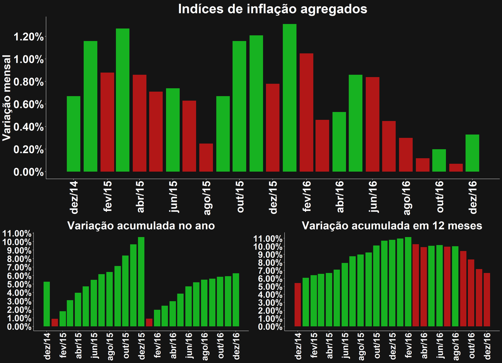

Índices selecionados para a média: IPCA, INPC e IGP-M.

# IPCA

|  | 12/2015 | 11/2016 | 12/2016 |
| --- | --- | --- | --- |
| Variação mensal | 0.96% | 0.18% | 0.3% |
| Variação acumulada no ano | 10.67% | 5.97% | 6.29% |
| Variação acumulada em 12 meses | 10.67% | 6.99% | 6.29% |

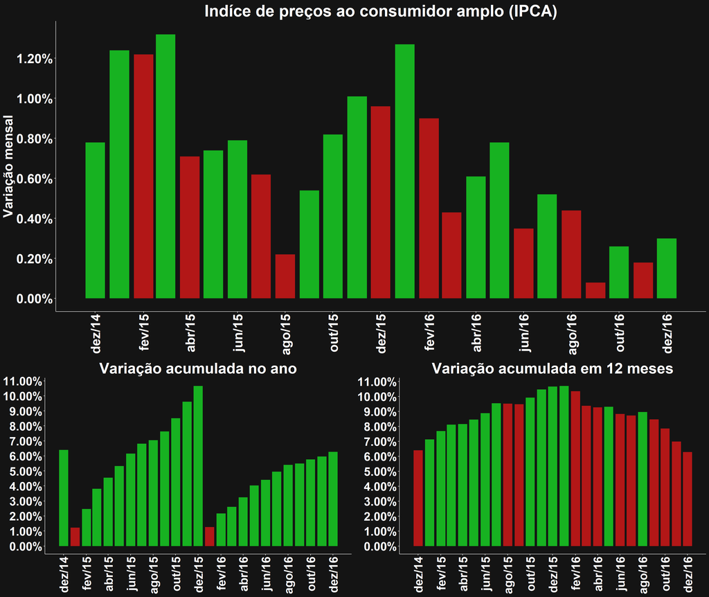

Os grupos que tiveram maior resultado positivo foram Transportes (1.11%) e Despesas pessoais (1.01%), e negativo Habitação (-0.59%) e Artigos de residência (-0.31%).

|  | Variação mensal | Variação acumulada no ano | Peso mensal |
| --- | --- | --- | --- |
| Alimentação e bebidas | 0.08% | 8.61% | 25.83% |
| Habitação | -0.59% | 2.84% | 15.37% |
| Artigos de residência | -0.31% | 3.41% | 4.18% |
| Vestuário | 0.32% | 3.54% | 5.96% |
| Transportes | 1.11% | 4.24% | 17.95% |
| Saúde e cuidados pessoais | 0.49% | 11.05% | 11.62% |
| Despesas pessoais | 1.01% | 8.01% | 10.73% |
| Educação | 0.07% | 8.87% | 4.65% |
| Comunicação | 0.02% | 1.27% | 3.7% |

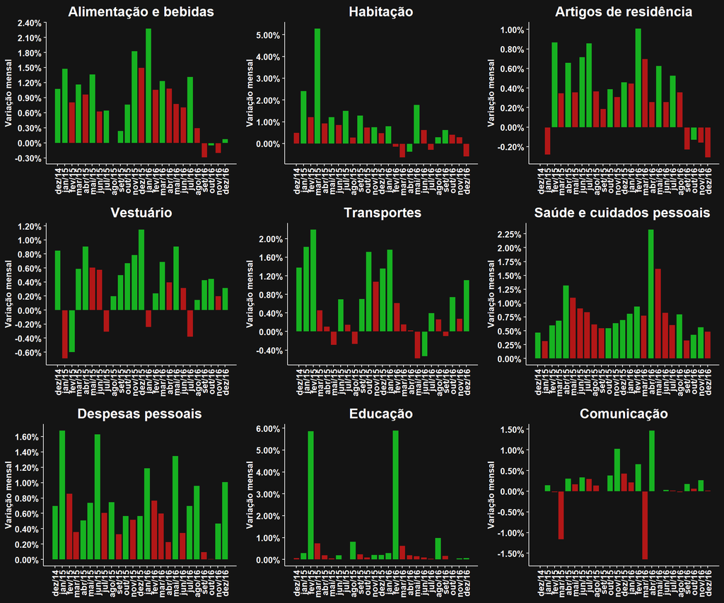

A nível de sub-itens os que mais influenciaram positivamente no resultado em relação ao seu peso foram Passagem aérea (26.29%%) e Gasolina (1.75%%), e negativamente Energia elétrica residencial (-3.7%%) e Feijão - carioca (rajado) (-13.77%%).

|  | Variação mensal | Variação acumulada no ano | Peso mensal |
| --- | --- | --- | --- |
| Cigarro | 4.8% | 16.02% | 1.03% |
| Passagem aérea | 26.29% | -4.9% | 0.37% |
| Gasolina | 1.75% | 2.53% | 3.89% |
| Plano de saúde | 1.07% | 13.57% | 3.52% |

|  | Variação mensal | Variação acumulada no ano | Peso mensal |
| --- | --- | --- | --- |
| Feijão - carioca (rajado) | -13.77% | 46.39% | 0.34% |
| Batata-inglesa | -16.12% | -29.03% | 0.22% |
| Energia elétrica residencial | -3.7% | -10.66% | 3.51% |
| Leite longa vida | -3.97% | 12.19% | 1% |

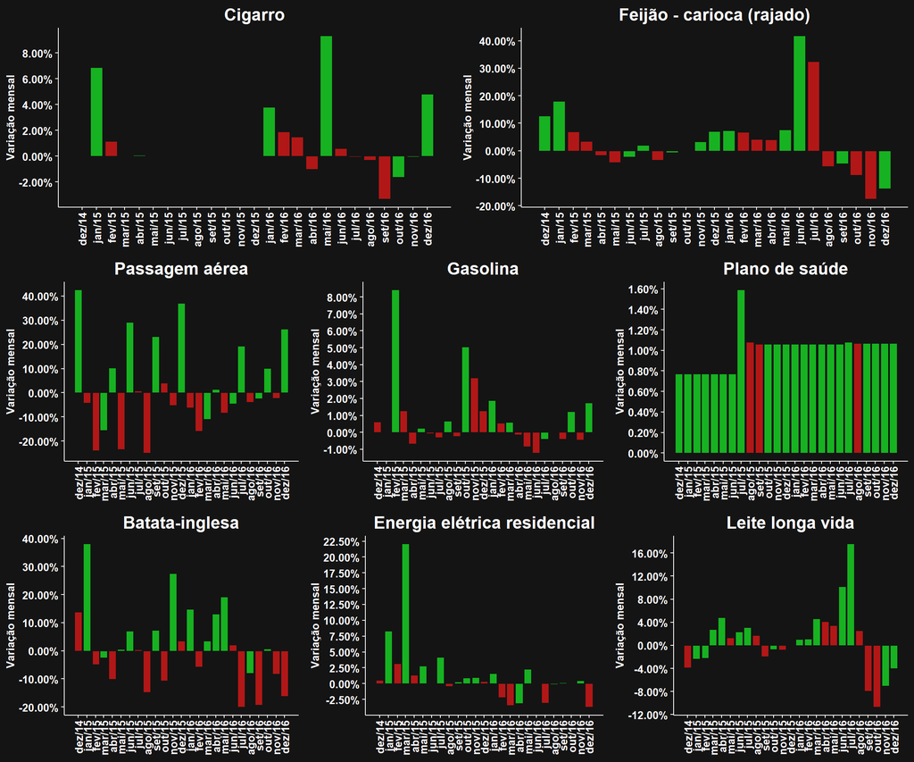

# INPC

|  | 12/2015 | 11/2016 | 12/2016 |
| --- | --- | --- | --- |
| Variação mensal | 0.9% | 0.07% | 0.14% |
| Variação acumulada no ano | 11.28% | 6.43% | 6.58% |
| Variação acumulada em 12 meses | 11.28% | 7.39% | 6.58% |

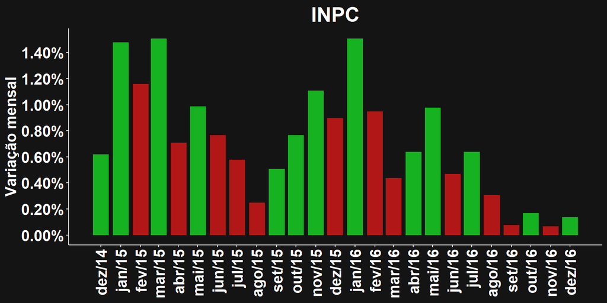

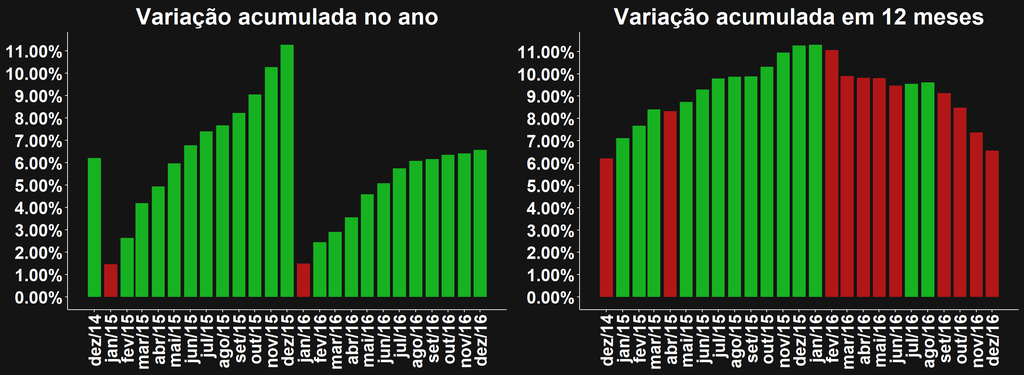

# IGP-M

O Indíce Geral de Preços de Mercado (IGP-M) variou 0.54% em dezembro, valor superior ao mesmo período do ano anterior quando apresentou uma taxa de 0.49%. Com esse resultado o indíce acumula no ano uma variação positiva de 5.97%, e em 12 meses uma variação positiva de 7.17%.

|  | 12/2015 | 11/2016 | 12/2016 |
| --- | --- | --- | --- |
| Variação mensal | 0.49% | -0.03% | 0.54% |
| Variação acumulada no ano | 9.7% | 5.4% | 5.97% |
| Variação acumulada em 12 meses | 10.54% | 7.12% | 7.17% |

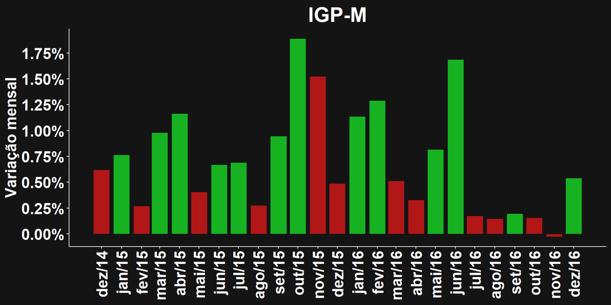

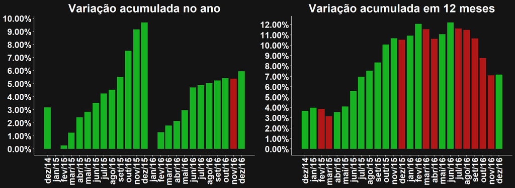

# IGP-DI

O Indíce Geral de Preços - Disponibilidade Interna (IGP-DI) variou 0.83% em dezembro, valor superior ao mesmo período do ano anterior quando apresentou uma taxa de 0.44%. Com esse resultado o indíce acumula no ano uma variação positiva de 5.57%, e em 12 meses uma variação positiva de 7.18%.

|  | 12/2015 | 11/2016 | 12/2016 |
| --- | --- | --- | --- |
| Variação mensal | 0.44% | 0.05% | 0.83% |
| Variação acumulada no ano | 9.97% | 4.7% | 5.57% |
| Variação acumulada em 12 meses | 10.7% | 6.77% | 7.18% |

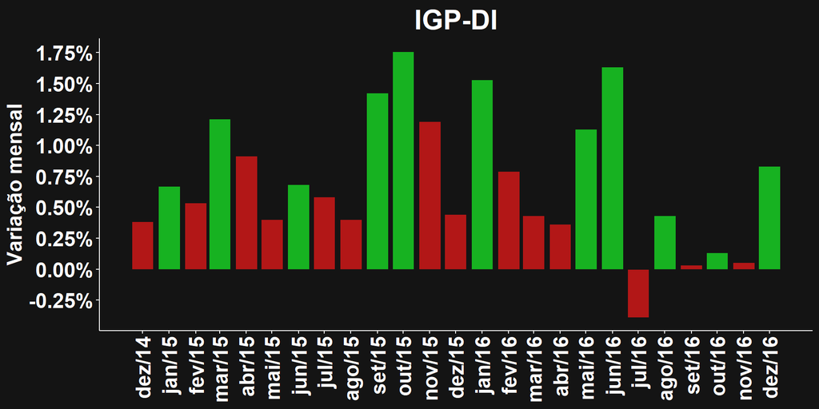

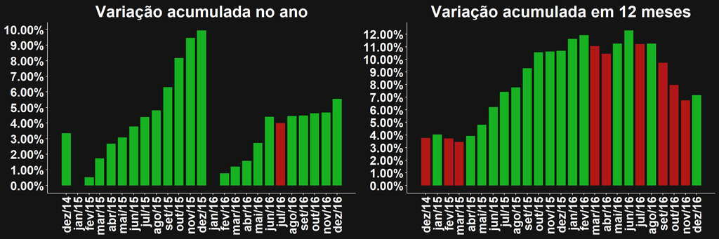

O Indíce de Preços de Atacado (IPA), integrante do IGP-DI com peso de 60%, apresentou variação de 1.1% em dezembro, valor superior ao mesmo período do ano anterior quando apresentou uma taxa de 0.33%. Com esse resultado o indíce acumula no ano uma variação positiva de 0.08%, e em 12 meses uma variação positiva de 0.08%.

|  | 12/2015 | 11/2016 | 12/2016 |
| --- | --- | --- | --- |
| Variação mensal | 0.33% | -0.01% | 1.1% |
| Variação acumulada no ano | 0.11% | 0.07% | 0.08% |
| Variação acumulada em 12 meses | 0.11% | 0.07% | 0.08% |

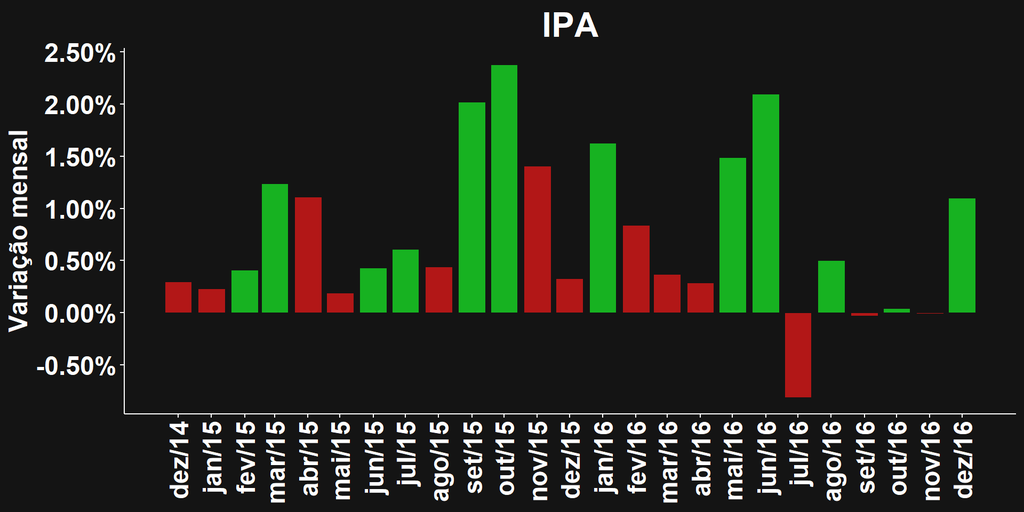

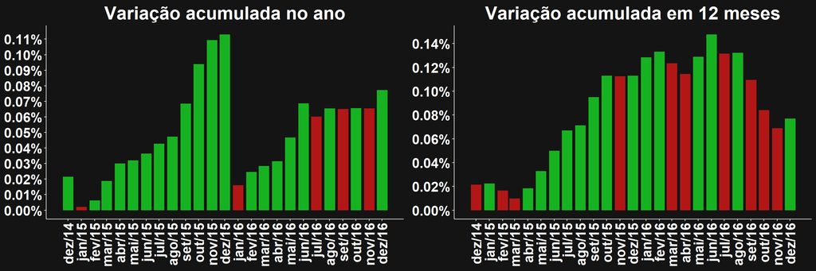

|  | 12/2015 | 11/2016 | 12/2016 |
| --- | --- | --- | --- |
| Variação mensal | 0.88% | 0.17% | 0.33% |
| Variação acumulada no ano | 8.65% | 3.98% | 4.32% |
| Variação acumulada em 12 meses | 10.53% | 6.76% | 6.18% |

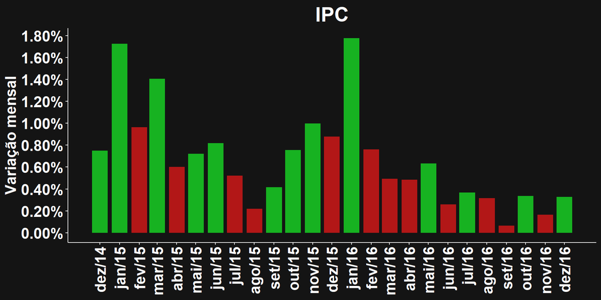

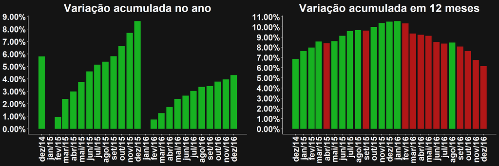

O Indíce Nacional de Custos de Construção (INCC), integrante do IGP-DI com peso de 10%, apresentou variação de 0.34% em dezembro, valor superior ao mesmo período do ano anterior quando apresentou uma taxa de 0.1%. Com esse resultado o indíce acumula no ano uma variação positiva de 5.71%, e em 12 meses uma variação positiva de 6.12%.

|  | 12/2015 | 11/2016 | 12/2016 |
| --- | --- | --- | --- |
| Variação mensal | 0.1% | 0.16% | 0.34% |
| Variação acumulada no ano | 6.5% | 5.35% | 5.71% |
| Variação acumulada em 12 meses | 7.48% | 5.87% | 6.12% |

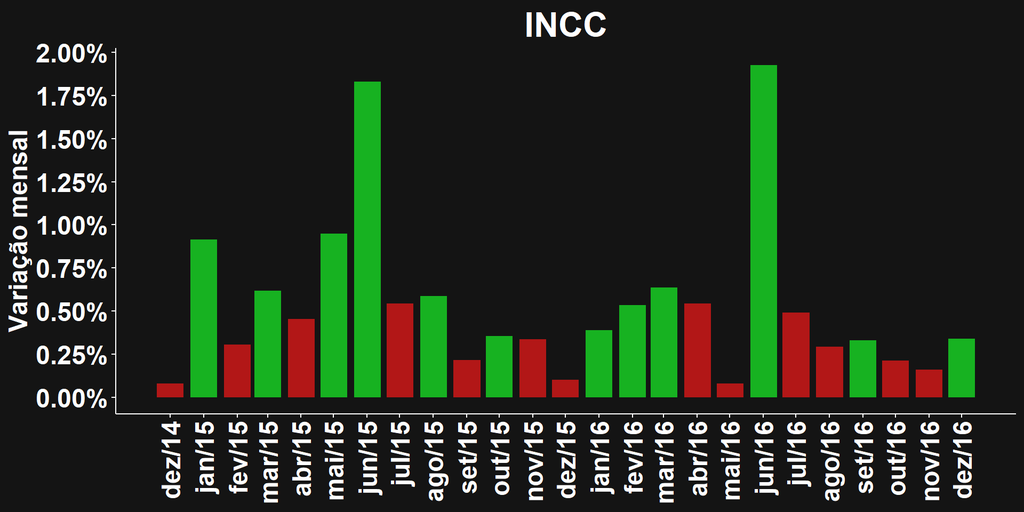

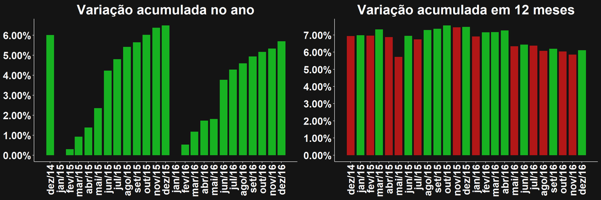

# Estatísticas

As estatísticas descritivas a seguir são feitas com base nos últimos 48 meses, e tem como objetivo possibilitar a avaliação do resultado observado em comparação aos períodos anteriores.

|  | Minimo | 1 Quartil | Mediana | Media | 3 Quartil | Maximo | Desvio Padrão |
| --- | --- | --- | --- | --- | --- | --- | --- |
| IPCA | 0.01% | 0.36% | 0.55% | 0.59% | 0.78% | 1.32% | 0.32% |
| INPC | -0.13% | 0.3% | 0.6% | 0.6% | 0.77% | 1.51% | 0.37% |
| IGP-M | -0.74% | 0.2% | 0.44% | 0.54% | 0.83% | 1.89% | 0.56% |
| IGP-DI | -0.63% | 0.26% | 0.45% | 0.55% | 0.83% | 1.76% | 0.56% |
| IPA | -1.21% | 0.08% | 0.39% | 0.53% | 1.02% | 2.38% | 0.82% |
| IPC | -0.17% | 0.33% | 0.52% | 0.59% | 0.76% | 1.78% | 0.39% |
| INCC | 0.08% | 0.29% | 0.45% | 0.58% | 0.65% | 2.25% | 0.51% |

Levando em consideração o desvio padrão de cada indíce, proporcionalmente os que mais se afastaram da média foram o INPC, o IPCA e o IPA.

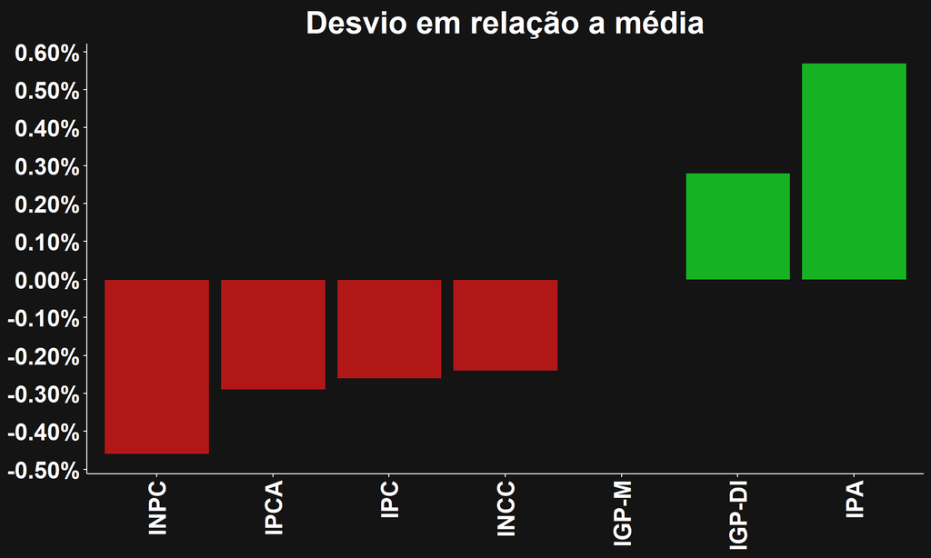

**João Victor Gomes**  
**jvg.santana@gmail.com**  
**[linkedin.com/in/jvictorgomes](https://www.linkedin.com/in/jvictorgomes/)**